# Homework 2

Shubham Shinde

2020-12-12

# Problem 1

- Choose a Problem from Analytic 2 or from an internet repositories.
- Compute a SVM and a model from Analytic 1 or 2. Compare both analysis. Compare the confusion matrices. Differences?
- Present your results.

## Telecom Churn Problem

Nowadays, telecom industry faces fierce com-petition in satisfying its customers. The role of churn prediction system is not only restricted to accurately predict churners but also to interpret customer churn behavior.

Cell2Cell dataset is preprocessed and a balanced version provided for analyzing Process. consists of 71,047 instances and 58 attributes. Guys you can try with data set. find measures like accuracy, ROC, AUC. Please find the link for the dataset [here](https://www.kaggle.com/jpacse/datasets-for-churn-telecom?select=cell2celltrain.csv)

### Data Import

```r
cell_churn <- read.csv("C:/Users/shubh/OneDrive - SRH IT/University/Semester 3/Analytics 3/Codes/cell2cellholdout.csv/cell2celltrain_sample.csv",stringsAsFactors = TRUE)
```

### Structure of the Data

```r
str(cell_churn)
```

```
## 'data.frame':    200 obs. of  59 variables:
##  $ X                        : int  1 2 3 4 5 6 7 8 9 10 ...
##  $ CustomerID               : int  3000002 3000010 3000026 3000082 3000122 3000158 3000174 3000182 3000190 3000194 ...
##  $ Churn                    : Factor w/ 2 levels "No","Yes": 2 2 2 2 2 2 2 2 2 2 ...
##  $ MonthlyRevenue           : num  24 17 17.1 172.4 24.5 ...
##  $ MonthlyMinutes           : int  219 10 0 1978 42 196 4 684 852 782 ...
##  $ TotalRecurringCharge     : int  22 17 17 100 17 30 17 55 85 25 ...
##  $ DirectorAssistedCalls    : num  0.25 0 0 0 0 0 0 0 0 0 ...
##  $ OverageMinutes           : int  0 0 0 362 10 0 0 3 0 233 ...
##  $ RoamingCalls             : num  0 0 0 0 0 2.6 0 0 0 0 ...
##  $ PercChangeMinutes        : int  -157 -4 0 -1007 81 54 -4 -2 -206 -258 ...
##  $ PercChangeRevenues       : num  -19 0 -0.2 -72.5 29.9 8.6 0 0.6 0 -80 ...
##  $ DroppedCalls             : num  0.7 0.3 0 7.3 0 6.7 0 15.7 10.7 1 ...
##  $ BlockedCalls             : num  0.7 0 0 18 0 0.3 1 1.3 6.3 0.7 ...
##  $ UnansweredCalls          : num  6.3 2.7 0 114.3 0 ...
```

[output cut: 45 more lines]

## Data Cleaning

```r
# ServiceArea_uniq <- unique(cell_churn$ServiceArea)
cell_churn <- na.omit(cell_churn)
cell_churn$ServiceArea <- gsub(" ","UNKNOWN",cell_churn$ServiceArea, fixed = TRUE)
```

## Descriptive Stats

```r
summary(cell_churn)
```

```
##        X           CustomerID      Churn    MonthlyRevenue   MonthlyMinutes
##  Min.   :  1.0   Min.   :3000002   No :98   Min.   :  5.00   Min.   :   0.0
##  1st Qu.: 52.0   1st Qu.:3000318   Yes:95   1st Qu.: 35.34   1st Qu.:  94.0
##  Median :102.0   Median :3000682            Median : 63.02   Median : 438.0
##  Mean   :101.2   Mean   :3000818            Mean   : 72.86   Mean   : 699.6
##  3rd Qu.:150.0   3rd Qu.:3001178            3rd Qu.: 94.99   3rd Qu.:1020.0
##  Max.   :200.0   Max.   :3002390            Max.   :316.47   Max.   :3808.0
##
##  TotalRecurringCharge DirectorAssistedCalls OverageMinutes     RoamingCalls
##  Min.   :  5.00       Min.   : 0.00         Min.   :   0.00   Min.   : 0.000
##  1st Qu.: 30.00       1st Qu.: 0.00         1st Qu.:   0.00   1st Qu.: 0.000
##  Median : 52.00       Median : 0.00         Median :   0.00   Median : 0.000
##  Mean   : 56.66       Mean   : 1.40         Mean   :  65.75   Mean   : 1.301
##  3rd Qu.: 75.00       3rd Qu.: 1.24         3rd Qu.:  38.00   3rd Qu.: 0.100
##  Max.   :213.00       Max.   :44.30         Max.   :1306.00   Max.   :41.300
##
##  PercChangeMinutes PercChangeRevenues  DroppedCalls     BlockedCalls
##  Min.   :-2239.0   Min.   :-106.80    Min.   : 0.000   Min.   : 0.000
##  1st Qu.: -113.0   1st Qu.:  -7.50    1st Qu.: 0.700   1st Qu.: 0.000
##  Median :   -6.0   Median :  -0.20    Median : 2.700   Median : 1.700
##  Mean   :  -57.9   Mean   :  -2.93    Mean   : 5.372   Mean   : 4.965
##  3rd Qu.:   53.0   3rd Qu.:   2.50    3rd Qu.: 6.700   3rd Qu.: 6.000
##  Max.   :  997.0   Max.   : 141.90    Max.   :52.000   Max.   :80.700
##
##  UnansweredCalls  CustomerCareCalls ThreewayCalls    ReceivedCalls
##  Min.   :  0.00   Min.   : 0.0000   Min.   :0.0000   Min.   :   0.0
##  1st Qu.:  4.70   1st Qu.: 0.0000   1st Qu.:0.0000   1st Qu.:   7.8
##  Median : 18.00   Median : 0.0000   Median :0.0000   Median :  87.2
##  Mean   : 30.16   Mean   : 0.8161   Mean   :0.1088   Mean   : 197.9
##  3rd Qu.: 41.00   3rd Qu.: 0.7000   3rd Qu.:0.0000   3rd Qu.: 282.6
##  Max.   :216.00   Max.   :11.3000   Max.   :2.0000   Max.   :1543.7
##
##  OutboundCalls     InboundCalls    PeakCallsInOut   OffPeakCallsInOut
##  Min.   :  0.00   Min.   :  0.00   Min.   :   0.0   Min.   :  0.00
##  1st Qu.:  3.30   1st Qu.:  0.00   1st Qu.:  19.7   1st Qu.:  7.00
##  Median : 15.70   Median :  2.70   Median :  85.7   Median : 28.00
##  Mean   : 30.73   Mean   : 14.15   Mean   : 167.2   Mean   : 53.84
##  3rd Qu.: 39.30   3rd Qu.: 14.00   3rd Qu.: 225.3   3rd Qu.: 67.30
##  Max.   :370.30   Max.   :196.00   Max.   :1177.3   Max.   :468.70
##
```

[output cut: 65 more lines]

```
##  No :183                 1-Highest:118   Other   :70   Clerical    :  7
##  Yes: 10                 2-High   :  6   Rural   :14   Crafts      :  5
##                          3-Good   : 41   Suburban:78   Homemaker   :  2
##                          4-Medium : 20   Town    :31   Other       :132
##                          5-Low    :  3                 Professional: 39
##                          6-VeryLow:  4                 Retired     :  1
##                          7-Lowest :  1                 Self        :  7
##  MaritalStatus
##  No     :55
##  Unknown:50
##  Yes    :88
##
##
##
##
```

## Information for processing data if categorical variables has more that 10 levels

Non-numerical data such as categorical data are common in practice. Some classification methods are adaptive to categorical predictor variables in nature, but some methods can be only applied to continuous numerical data. Among the three classification methods, only Kernel Density Classification can handle the categorical variables in theory, while kNN and SVM are unable to be applied directly since they are based on the Euclidean distances. In order to define the distance metrics for categorical variables, the first step of preprocessing of the dataset is to use dummy variables to represent the categorical variables.

Secondly, due to the distinct natures of categorical and numerical data, we usually need to standardize the numerical variables, such as the contributions to the euclidean distances from a numerical variable and a categorical variable are basically on the same level.

Finally, the introduction of dummy variables usually increase the dimension significantly. By various experiments, we find that dimension reduction techniques such as PCA usually improve the performance of these three classifiers significantly. # https://stats.libretexts.org/Bookshelves/Computing_and_Modeling/RTG%3A_Classification_Methods/4%3A_Numerical_Experiments_and_Real_Data_Analysis/Preprocessing_of_categorical_predictors_in_SVM%2C_KNN_and_KDC_(contributed_by_Xi_Cheng)

## SVM

```r
m <- svm(Churn~CustomerID+MonthlyRevenue+MonthlyMinutes+TotalRecurringCharge+DirectorAssistedCalls+OverageMinutes+
           RoamingCalls+PercChangeMinutes+PercChangeRevenues+DroppedCalls+BlockedCalls+UnansweredCalls+
           CustomerCareCalls+ThreewayCalls+ReceivedCalls+OutboundCalls+InboundCalls+PeakCallsInOut+
           OffPeakCallsInOut+DroppedBlockedCalls+CallForwardingCalls+CallWaitingCalls+MonthsInService+
           UniqueSubs+ActiveSubs+Handsets +HandsetModels +CurrentEquipmentDays +AgeHH1 +AgeHH2 +ChildrenInHH
         +HandsetRefurbished +HandsetWebCapable +TruckOwner +RVOwner +Homeownership +BuysViaMailOrder
         +RespondsToMailOffers +OptOutMailings +NonUSTravel +OwnsComputer +HasCreditCard +RetentionCalls
         +RetentionOffersAccepted +NewCellphoneUser +NotNewCellphoneUser +ReferralsMadeBySubscriber
         +IncomeGroup +OwnsMotorcycle +AdjustmentsToCreditRating +HandsetPrice +MadeCallToRetentionTeam
         +CreditRating +PrizmCode +Occupation +MaritalStatus, data = cell_churn)
```

Summary of the SVM Model

```r
summary(m)
```

```
##
## Call:
## svm(formula = Churn ~ CustomerID + MonthlyRevenue + MonthlyMinutes +
##     TotalRecurringCharge + DirectorAssistedCalls + OverageMinutes +
##     RoamingCalls + PercChangeMinutes + PercChangeRevenues + DroppedCalls +
##     BlockedCalls + UnansweredCalls + CustomerCareCalls + ThreewayCalls +
##     ReceivedCalls + OutboundCalls + InboundCalls + PeakCallsInOut +
##     OffPeakCallsInOut + DroppedBlockedCalls + CallForwardingCalls +
##     CallWaitingCalls + MonthsInService + UniqueSubs + ActiveSubs +
##     Handsets + HandsetModels + CurrentEquipmentDays + AgeHH1 + AgeHH2 +
##     ChildrenInHH + HandsetRefurbished + HandsetWebCapable + TruckOwner +
##     RVOwner + Homeownership + BuysViaMailOrder + RespondsToMailOffers +
##     OptOutMailings + NonUSTravel + OwnsComputer + HasCreditCard +
##     RetentionCalls + RetentionOffersAccepted + NewCellphoneUser +
##     NotNewCellphoneUser + ReferralsMadeBySubscriber + IncomeGroup +
##     OwnsMotorcycle + AdjustmentsToCreditRating + HandsetPrice + MadeCallToRetentionTeam +
##     CreditRating + PrizmCode + Occupation + MaritalStatus, data = cell_churn)
##
##
## Parameters:
##    SVM-Type:  C-classification
##  SVM-Kernel:  radial
##        cost:  1
##
## Number of Support Vectors:  163
##
##  ( 83 80 )
##
##
## Number of Classes:  2
##
## Levels:
##  No Yes
```

Creation of Test Data for model prediction

```r
test_data <- cell_churn[1:50,]
new_data = test_data[1,]
```

Data Cleaning for the newdata i.e prediction

```r
new_data$HandsetPrice <- as.numeric(new_data$HandsetPrice)
new_data <- na.omit(new_data)
```

Predict Data

```r
predict(m, newdata = new_data)
```

```
##  1
## No
## Levels: No Yes
```

Confusion Matrix of SVM Model

```r
svm_cm <- confusionMatrix(predict(m, type = "class" ), reference = cell_churn$Churn)
svm_cm
```

```
## Confusion Matrix and Statistics
##
##           Reference
## Prediction No Yes
##        No  93  22
##        Yes  5  73
##
##                Accuracy : 0.8601
##                  95% CI : (0.803, 0.9057)
##     No Information Rate : 0.5078
##     P-Value [Acc > NIR] : < 2.2e-16
##
##                   Kappa : 0.7194
##
##  Mcnemar's Test P-Value : 0.002076
##
##             Sensitivity : 0.9490
##             Specificity : 0.7684
##          Pos Pred Value : 0.8087
##          Neg Pred Value : 0.9359
##              Prevalence : 0.5078
##          Detection Rate : 0.4819
##    Detection Prevalence : 0.5959
##       Balanced Accuracy : 0.8587
##
##        'Positive' Class : No
##
```

## Decision Tree

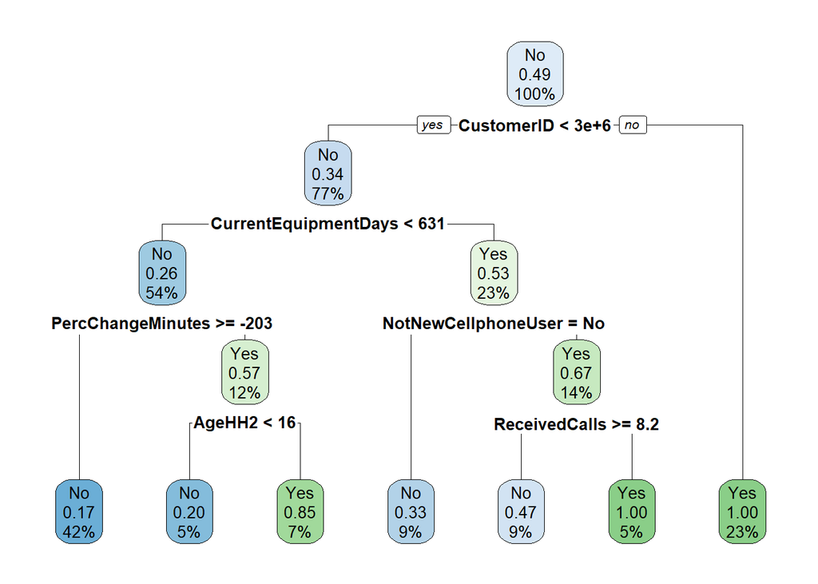

```r
new_data <- na.omit(new_data)
dc_tree <- rpart(Churn~CustomerID+MonthlyRevenue+MonthlyMinutes+TotalRecurringCharge+DirectorAssistedCalls+OverageMinutes+
        RoamingCalls+PercChangeMinutes+PercChangeRevenues+DroppedCalls+BlockedCalls+UnansweredCalls+
        CustomerCareCalls+ThreewayCalls+ReceivedCalls+OutboundCalls+InboundCalls+PeakCallsInOut+
        OffPeakCallsInOut+DroppedBlockedCalls+CallForwardingCalls+CallWaitingCalls+MonthsInService+
        UniqueSubs+ActiveSubs+Handsets +HandsetModels +CurrentEquipmentDays +AgeHH1 +AgeHH2 +ChildrenInHH
      +HandsetRefurbished +HandsetWebCapable +TruckOwner +RVOwner +Homeownership +BuysViaMailOrder
      +RespondsToMailOffers +OptOutMailings +NonUSTravel +OwnsComputer +HasCreditCard +RetentionCalls
      +RetentionOffersAccepted +NewCellphoneUser +NotNewCellphoneUser +ReferralsMadeBySubscriber
      +IncomeGroup +OwnsMotorcycle +AdjustmentsToCreditRating +HandsetPrice +MadeCallToRetentionTeam
      +CreditRating +PrizmCode +Occupation +MaritalStatus, data = cell_churn)

rpart.plot(dc_tree)
```

Predict Data for Decision Tree Model

```r
predict(dc_tree, newdata = new_data, type = 'class')
```

```
##  1
## No
## Levels: No Yes
```

Confusion Matrix for Decision Tree Model

```r
table(true=cell_churn$Churn, predicted=predict(dc_tree, type = "class" ))
```

```
##      predicted
## true  No Yes
##   No  96   2
##   Yes 30  65
```

```r
dt_cm <- confusionMatrix(predict(dc_tree, type = "class" ), reference = cell_churn$Churn)
```

## Confusion Metrics of Both Algos from Problem 1

```r
dt_cm
```

```
## Confusion Matrix and Statistics
##
##           Reference
## Prediction No Yes
##        No  96  30
##        Yes  2  65
##
##                Accuracy : 0.8342
##                  95% CI : (0.7741, 0.8837)
##     No Information Rate : 0.5078
##     P-Value [Acc > NIR] : < 2.2e-16
##
##                   Kappa : 0.6668
##
##  Mcnemar's Test P-Value : 1.815e-06
##
##             Sensitivity : 0.9796
##             Specificity : 0.6842
##          Pos Pred Value : 0.7619
##          Neg Pred Value : 0.9701
##              Prevalence : 0.5078
##          Detection Rate : 0.4974
##    Detection Prevalence : 0.6528
##       Balanced Accuracy : 0.8319
##
##        'Positive' Class : No
##
```

```r
svm_cm
```

```
## Confusion Matrix and Statistics
##
##           Reference
## Prediction No Yes
##        No  93  22
##        Yes  5  73
##
##                Accuracy : 0.8601
##                  95% CI : (0.803, 0.9057)
##     No Information Rate : 0.5078
##     P-Value [Acc > NIR] : < 2.2e-16
##
##                   Kappa : 0.7194
##
##  Mcnemar's Test P-Value : 0.002076
##
##             Sensitivity : 0.9490
##             Specificity : 0.7684
##          Pos Pred Value : 0.8087
##          Neg Pred Value : 0.9359
##              Prevalence : 0.5078
##          Detection Rate : 0.4819
##    Detection Prevalence : 0.5959
##       Balanced Accuracy : 0.8587
##
##        'Positive' Class : No
##
```

# Problem 2

- Compare the SVM regression with a linear regression.
- Visualize your results.
- For SVM and linear model, Compute the RMSE, root mean square error: Compare the RMSE between the SVM and linear model.

## Data Import Problem 2

```r
insurance <- read.csv("C:/Users/shubh/OneDrive - SRH IT/University/Semester 3/Analytics 3/Codes/insurance.csv", stringsAsFactors = TRUE)
```

## Head

```r
head(insurance)
```

```
##   age    sex    bmi children smoker    region   charges
## 1  19 female 27.900        0    yes southwest 16884.924
## 2  18   male 33.770        1     no southeast  1725.552
## 3  28   male 33.000        3     no southeast  4449.462
## 4  33   male 22.705        0     no northwest 21984.471
## 5  32   male 28.880        0     no northwest  3866.855
## 6  31 female 25.740        0     no southeast  3756.622
```

## Str

```r
str(insurance)
```

```
## 'data.frame':    1338 obs. of  7 variables:
##  $ age     : int  19 18 28 33 32 31 46 37 37 60 ...
##  $ sex     : Factor w/ 2 levels "female","male": 1 2 2 2 2 1 1 1 2 1 ...
##  $ bmi     : num  27.9 33.8 33 22.7 28.9 ...
##  $ children: int  0 1 3 0 0 0 1 3 2 0 ...
##  $ smoker  : Factor w/ 2 levels "no","yes": 2 1 1 1 1 1 1 1 1 1 ...
##  $ region  : Factor w/ 4 levels "northeast","northwest",..: 4 3 3 2 2 3 3 2 1 2 ...
##  $ charges : num  16885 1726 4449 21984 3867 ...
```

## Data Cleaning

```r
insurance <- na.omit(insurance)
```

## Data Train Test Split

```r
train_data <-  insurance[1:(nrow(insurance)*0.7),]
test_data <-  insurance[(nrow(insurance)*0.7):nrow(insurance),]
```

## Linear Regression

```r
lin.reg <- lm(charges ~ ., data = train_data)
summary(lin.reg)
```

```
##
## Call:
## lm(formula = charges ~ ., data = train_data)
##
## Residuals:
##      Min       1Q   Median       3Q      Max
## -11223.2  -2718.4   -852.9   1290.9  25019.9
##
## Coefficients:
##                  Estimate Std. Error t value Pr(>|t|)
## (Intercept)     -11979.09    1168.28 -10.254  < 2e-16 ***
## age                258.40      13.61  18.982  < 2e-16 ***
## sexmale           -446.85     386.38  -1.156  0.24778
## bmi                341.12      33.41  10.210  < 2e-16 ***
## children           420.62     162.05   2.596  0.00959 **
## smokeryes        24104.18     486.43  49.553  < 2e-16 ***
## regionnorthwest   -422.73     559.29  -0.756  0.44994
## regionsoutheast  -1163.20     548.49  -2.121  0.03421 *
## regionsouthwest  -1049.99     549.85  -1.910  0.05649 .
## ---
## Signif. codes:  0 '***' 0.001 '**' 0.01 '*' 0.05 '.' 0.1 ' ' 1
##
## Residual standard error: 5877 on 927 degrees of freedom
## Multiple R-squared:  0.7636, Adjusted R-squared:  0.7615
## F-statistic: 374.2 on 8 and 927 DF,  p-value: < 2.2e-16
```

### Predict

```r
ypred <- predict(lin.reg, newdata = test_data)
```

### RMSE Metric

```r
lm.rmse <- RMSE(y_pred = ypred, y_true = test_data$charges)
```

## Decision Tree

```r
d.t <- rpart(charges ~ ., data = train_data)
summary(d.t)
```

```
## Call:
## rpart(formula = charges ~ ., data = train_data)
##   n= 936
##
##           CP nsplit rel error    xerror       xstd
## 1 0.62658931      0 1.0000000 1.0027512 0.06236317
## 2 0.13887142      1 0.3734107 0.3752114 0.02162994
## 3 0.07177794      2 0.2345393 0.2367973 0.01648494
## 4 0.01000000      3 0.1627613 0.1662845 0.01464634
##
## Variable importance
## smoker    bmi    age region    sex
##     72     16      9      2      1
##
## Node number 1: 936 observations,    complexity param=0.6265893
##   mean=13113.53, MSE=1.446931e+08
##   left son=2 (752 obs) right son=3 (184 obs)
##   Primary splits:
##       smoker   splits as  LR,          improve=0.626589300, (0 missing)
##       age      < 41.5    to the left,  improve=0.078219360, (0 missing)
##       bmi      < 31.145  to the left,  improve=0.042729450, (0 missing)
##       region   splits as  RLRL,        improve=0.006341228, (0 missing)
##       children < 1.5     to the left,  improve=0.005219799, (0 missing)
##
## Node number 2: 752 observations,    complexity param=0.07177794
##   mean=8403.586, MSE=3.521826e+07
##   left son=4 (449 obs) right son=5 (303 obs)
##   Primary splits:
##       age      < 45.5    to the left,  improve=0.367053300, (0 missing)
##       bmi      < 20.955  to the left,  improve=0.017579220, (0 missing)
##       children < 1.5     to the left,  improve=0.012716970, (0 missing)
##       sex      splits as  RL,          improve=0.009432863, (0 missing)
##       region   splits as  RLLL,        improve=0.004841065, (0 missing)
##   Surrogate splits:
##       bmi < 35.8375 to the left,  agree=0.602, adj=0.013, (0 split)
##
## Node number 3: 184 observations,    complexity param=0.1388714
##   mean=32362.85, MSE=1.309126e+08
##   left son=6 (87 obs) right son=7 (97 obs)
##   Primary splits:
##       bmi      < 30.105  to the left,  improve=0.780795600, (0 missing)
##       age      < 53.5    to the left,  improve=0.108485700, (0 missing)
##       region   splits as  LLRL,        improve=0.010809610, (0 missing)
##       children < 1.5     to the left,  improve=0.007712422, (0 missing)
##       sex      splits as  LR,          improve=0.001823302, (0 missing)
##   Surrogate splits:
##       region splits as  LLRR,        agree=0.576, adj=0.103, (0 split)
##       sex    splits as  LR,          agree=0.554, adj=0.057, (0 split)
##       age    < 21.5    to the left,  agree=0.543, adj=0.034, (0 split)
##
## Node number 4: 449 observations
##   mean=5450.021, MSE=2.0557e+07
##
## Node number 5: 303 observations
##   mean=12780.32, MSE=2.486122e+07
##
## Node number 6: 87 observations
##   mean=21687.41, MSE=2.718915e+07
##
## Node number 7: 97 observations
##   mean=41937.73, MSE=3.004868e+07
```

### Plot Model Decision Tree

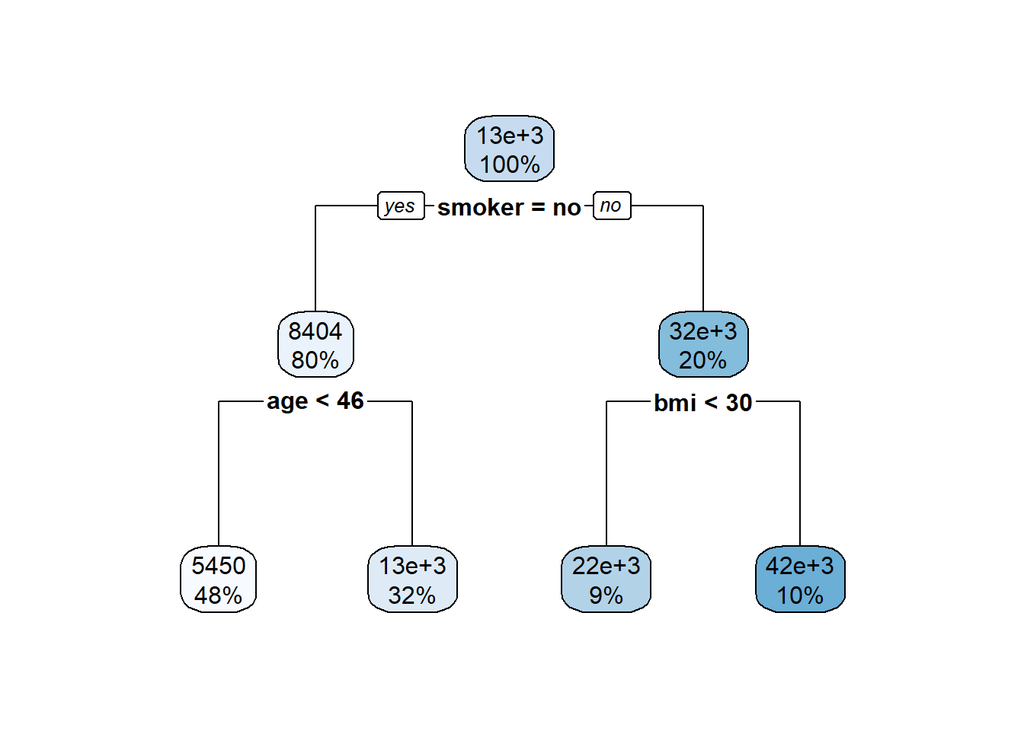

```r
rpart.plot(d.t)
```

### Predict

```r
ypred_dt <- predict(d.t, newdata = test_data)
```

### RMSE Metric

```r
dt.rmse <- RMSE(y_pred = ypred_dt, y_true = test_data$charges)
```

## SVM

```r
s.v.m <- svm(charges ~ ., data = train_data)
summary(s.v.m)
```

```
##
## Call:
## svm(formula = charges ~ ., data = train_data)
##
##
## Parameters:
##    SVM-Type:  eps-regression
##  SVM-Kernel:  radial
##        cost:  1
##       gamma:  0.1111111
##     epsilon:  0.1
##
##
## Number of Support Vectors:  351
```

### Predict

```r
ypred_svm <- predict(s.v.m, newdata = test_data)
```

### RMSE Metric

```r
svm.rmse <- RMSE(y_pred = ypred_svm, y_true = test_data$charges)
```

### Compare RMSE for all the models for Problem 2

```r
lm.rmse
```

```
## [1] 6472.332
```

```r
dt.rmse
```

```
## [1] 5508.171
```

```r
svm.rmse
```

```
## [1] 5438.394
```